# Random Survival Forests

Aleksandr Savenkov

11/21/2017

## Introduction

- An ensemble method for right-censored data
- Extension of *random forests*
- Based on H. Ishwaran, et al., **Random Survival Forests**, *The Annals of Applied Statistics*, 841-860, 2008
- Citations in 2017: *“Nature Genetics”*, *“Clinical Cancer Research”*, *“Nature Medicine”*, *“PloS one”*, etc

## Random forests

- Two forms of randomization:
  - random bootstrapped sample
  - random subset of variables at each node split
- Applications:
  - regression and classifiction problems

## Random forest

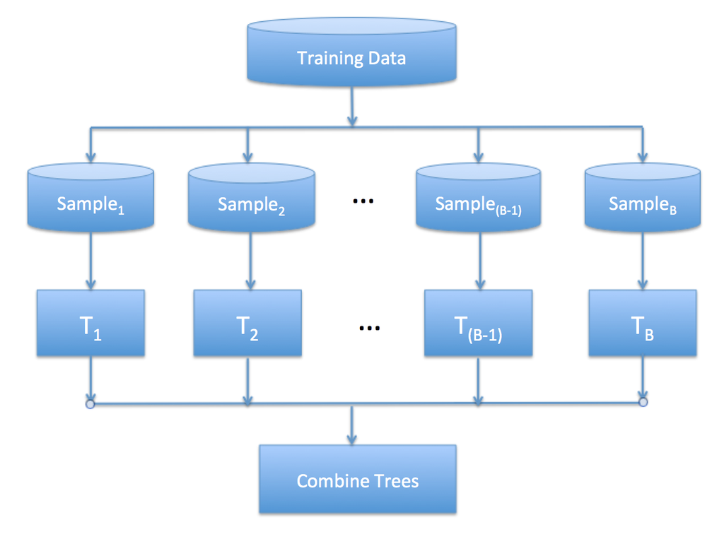

## OOB samples

- Probability for a data point to be selected for an OOB sample:
  $$\left(1 - \frac{1}{n}\right)^n \approx \exp(-1) = 0.368$$
- Training data will contain approximately $63.2\%$ of the original data

## OOB Samples

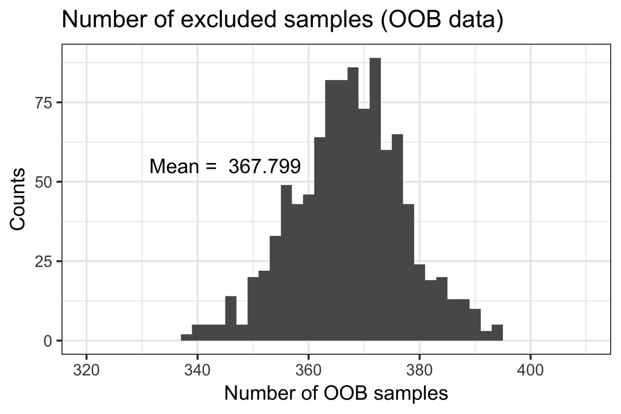

## Survival data

- methods with restrictive assumptions: proportional hazards
- ad hoc methods to detect nonlinear effects
- identifying interaction terms are problematic
  - brute force for all two-way or three-way interactions
  - subject knowledge to narrow the search

## Forest approaches

- Hothorn,
  - R packages: **party** and **partykit**
- Zhu and Kosorok, recursively imputed survival tree
- Ishwaran
  - R package: **randomForestSRC**

## RSF algorithm

- Draw B bootstrap samples from the original data
- Grow a survival tree for each bootstrap sample
- Calculate a cumulative hazard function (CHF) for each tree
- Average to obtain the ensemble CHF
- Calculate prediction error for the ensemble CHF, using OOB data

## Survival tree

- Survival trees are binary trees
- Start at the root node
- split into two nodes using a survival criterion
  - log-rank: splits by maximazation of the log-rank test statistics
  - log-rank score: standardized log-rank statistics
  - custom (require some efforts)

## Survival tree

- a node should contain a minimum $d_0 > 0$ unique events
- CHF is estimated by a Nelson-Aalen estimator

## Prediction error

- Harrell’s concordance index, C-index (Harrell et al., 1982)
- C-index specifically acounts for censoring

## Concordance index

- Form all possible pairs of cases over the data
- omit the pairs if shorter survival time is censored
- omit $(i, j)$ if $T_i = T_j$ unless at least on is an event
- For a permissible pair:
  - for $T_i \neq T_j$, count 1 if shorter survival time has worse predicted outcome, 0.5 if tied
  - for $T_i = T_j$ and both are events count 1 if predictions are tied and 0.5 otherwise. If not both events, 1 if event has worse predicted outcome, 0.5 otherwise

## Data description

- **breast** - Wisconsin Prognostic Breast Cancer Data
  - 198 observations with 32 covariates
  - outcome: R = recurrent, N = non-recurrent
  - the first 30 covariates are computed from a digitized image
- **breast10** - **breast** plus 10 uniform iid random variables
- **breast50** - **breast** plus 50 uniform iid random variables

## Simmulations (from Ishwaran, 2008)

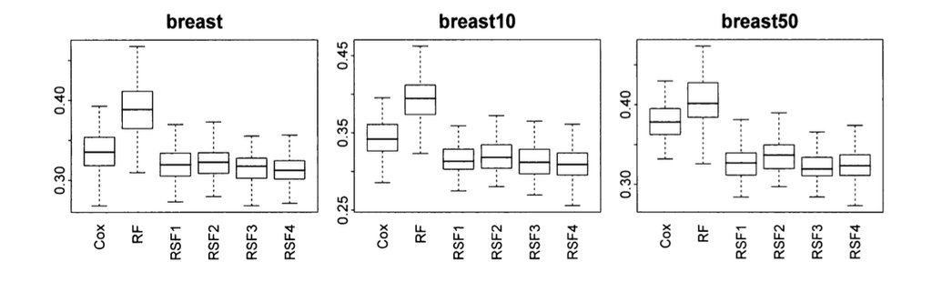

## References

1. H. Ishwaran, et al., **Random Survival Forests**, *The Annals of Applied Statistics*, 841-860, 2008
2. L. Breiman, **Random Forests**, *Machine Learning*, 5-32, 2001
3. Ishwaran H. and Kogalur U.B. (2017). **randomForestSRC** Random Forests for Survival, Regression, and Classification, R package version 2.5.0.
4. T. Hothorn, et al., **Survival Ensembles**, *Biostatistics*, 355-373
5. Zhu R., Kosorok M., **Recursively imputed survival trees**, *JASA*, 331-340, 2012